# Statistical Analysis of Omic Data

> Note: This the homework done by me to present some results. I will write both in English and Chinese.

> 注意：我做这份作业来展示一些结果。我将会用英语和中文两种语言来书写。

# 1 Part-2: multivariate analysis of omic data

## 1.1 Dimensional reduction (I): Variance filtering + clustering

Variance filtering: one of the simplest dimensional reduction methods is to **filter the features by variability across samples**.

Exercise: for two sets of 50 genes, draw their expression values from two Gaussians that differ in variance, say $σ_1=0.25$ and $σ_2=1$. Then introduce one big outlier for the 50 genes with lowest variance. Rank genes by variance and compare to ranking them by MAD.

Steps:

1. Compute variance of each feature across all samples.
2. Rank features according to variance.
3. Select a specified number of top features (e.g top 25%).
4. Perform clustering analysis on this reduced subset (e.g hierarchical clustering).

Since variance is sensitive to outliers, a more robust criterion than variance is to use the Median Absolute Deviation (MAD):

$$MAD = meadian(| X_i - meadian(X) | )$$

方差滤波：最简单的降维方法之一，它通过样本间的变异性来过滤特征。 练习: 对于两组50基因, 从两个不同的高斯中得出它们的表达式值,方差的参数为：$σ_1=0.25$ $σ_2=1$。然后引入一个很大的异常值, 50 个方差最低的基因。按方差排列基因, 并与它们进行比较。

计算步骤：

1. 在所有样本中计算每个特征的方差。
2. 按方差大小排列特征。
3. 选择指定数量的特征 (如前 25%)。
4. 对这些指定数量的特征进行聚类分析 (例如：层次聚类)。

由于方差对异常点敏感, 所以比方差更稳健的标准是使用中值绝对偏差 (MAD)。

### 1.1.1 when sigma = 0.25

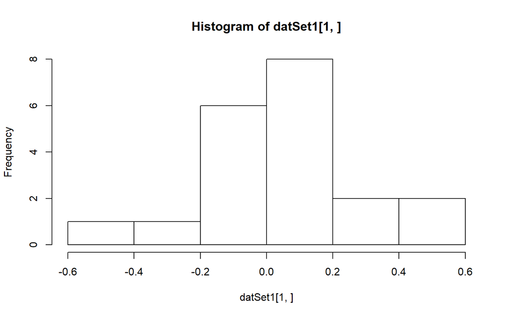

```r
sampleSize <- 20
featureSize <- 50
top <- 0.25
# Create matrix that row correspond to genes/features
datSet1 <- matrix(0, nrow = featureSize, ncol = sampleSize)
rownames(datSet1) <- paste0("gene_", 1:featureSize)
# assign the Gaussians distribution to each row
assignNormDis <- function(arg) {
    res <- rnorm(n = sampleSize, sd = 0.25)
    return(res)
}
set.seed(123)  # set seed so it could be repeatable
# use apply to avoid explict for loop
datSet1 <- t(apply(datSet1, 1, assignNormDis))  # need to Transpose
# let's see the first gene expression across samples to see if it subject to
# normal distribution.
hist(datSet1[1, ])
```

```r
# select the top 25% highest features of variance
sd_of_rows <- apply(datSet1, 1, sd)
row_indice_top <- order(sd_of_rows, decreasing = T)[1:round(featureSize * top)]
select_datSet <- datSet1[row_indice_top, ]
# the feature index of lowest variance
row_index_lowest <- order(sd_of_rows, decreasing = T)[featureSize]
cat(paste0("The gene with lowest variance is ", rownames(datSet1)[row_index_lowest]))
```

```
The gene with lowest variance is gene_6
```

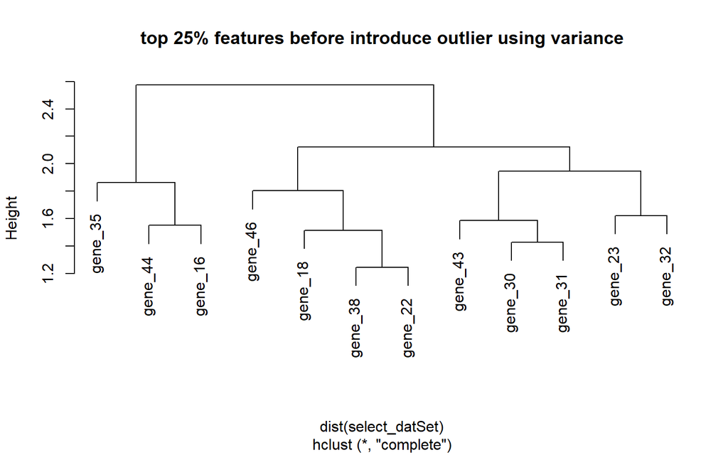

```r
# hierarchical clustering use Cluster method : complete Distance : euclidean
p <- hclust(dist(select_datSet))
plot(p, main = "top 25% features before introduce outlier using variance")
```

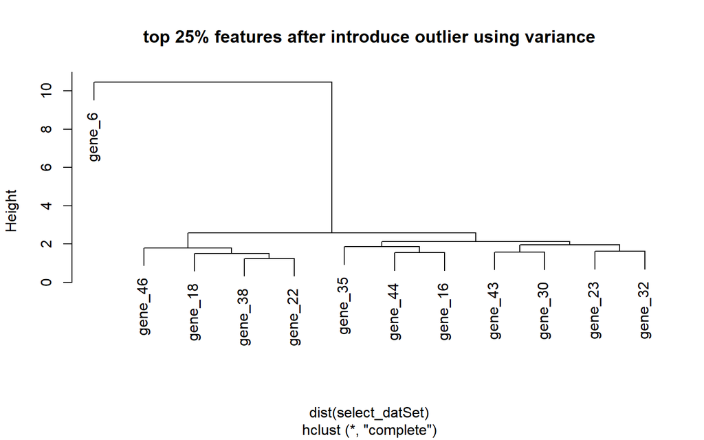

```r
# now let's introduce the big outlier
intro_outlier_datSet1 <- datSet1
intro_outlier_datSet1[row_index_lowest, 1] <- 10

sd_of_rows <- apply(intro_outlier_datSet1, 1, sd)
row_indice_top <- order(sd_of_rows, decreasing = T)[1:round(featureSize * top)]
select_datSet <- intro_outlier_datSet1[row_indice_top, ]

p <- hclust(dist(select_datSet))
plot(p, main = "top 25% features after introduce outlier using variance")
```

```r
# use MAD instead of sd
MAD <- function(x) {
    center = median(x)
    res <- median(abs(x - center))
    return(res)
}
mad_of_rows <- apply(datSet1, 1, MAD)
row_indice_top <- order(mad_of_rows, decreasing = T)[1:round(featureSize * top)]
select_datSet <- datSet1[row_indice_top, ]
# the feature index of lowest variance
row_index_lowest <- order(mad_of_rows, decreasing = T)[featureSize]
cat(paste0("The gene with lowest MAD is ", rownames(datSet1)[row_index_lowest]))
```

```
The gene with lowest MAD is gene_47
```

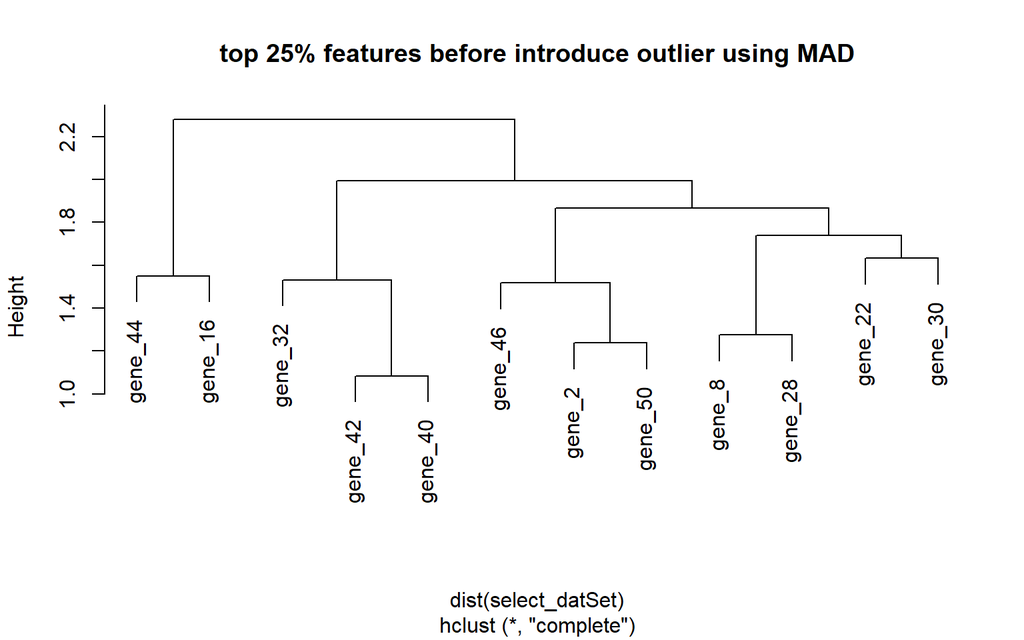

```r
# plot
p <- hclust(dist(select_datSet))
plot(p, main = "top 25% features before introduce outlier using MAD")
```

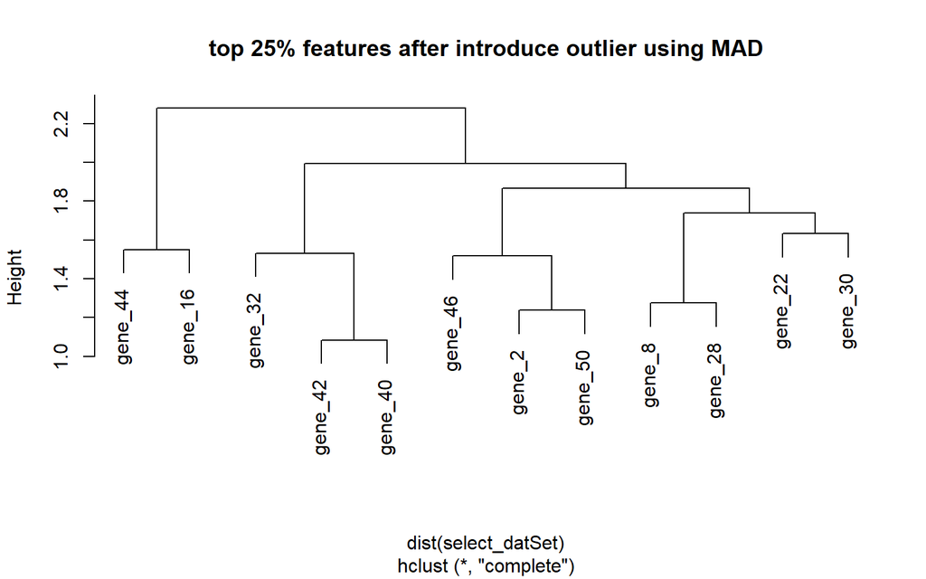

```r
# now let's introduce the big outlier
intro_outlier_datSet1 <- datSet1
intro_outlier_datSet1[row_index_lowest, 1] <- 10

sd_of_rows <- apply(intro_outlier_datSet1, 1, MAD)
row_indice_top <- order(sd_of_rows, decreasing = T)[1:round(featureSize * top)]
select_datSet <- intro_outlier_datSet1[row_indice_top, ]

p <- hclust(dist(select_datSet))
plot(p, main = "top 25% features after introduce outlier using MAD")
```

We can clearly see that MAD is much more robust than variance. Next let’s see the results when sigma = 1.

可以很清晰的看到，MAD这个衡量变异的统计量对于离群值更加稳健！下面我们来看看对于标准差为1的模拟数据的情况。

**Question1: Other cluster methods include “ward.D”, “ward.D2”, “single”, “complete”, “average” (= UPGMA), “mcquitty” (= WPGMA), “median” (= WPGMC) or “centroid” (= UPGMC). does it matters for us to cluster ?**

**Question2: mad() is the built-in MAD function, why the source code of mad() not equal to my function?**

```r
MAD(1:10) == mad(x = 1:10)
```

```
[1] FALSE
```

```r
# source code
mad
```

```
function (x, center = median(x), constant = 1.4826, na.rm = FALSE,
    low = FALSE, high = FALSE)
{
    if (na.rm)
        x <- x[!is.na(x)]
    n <- length(x)
    constant * if ((low || high) && n%%2 == 0) {
        if (low && high)
            stop("'low' and 'high' cannot be both TRUE")
        n2 <- n%/%2 + as.integer(high)
        sort(abs(x - center), partial = n2)[n2]
    }
    else median(abs(x - center))
}
<bytecode: 0x00000000165654f8>
<environment: namespace:stats>
```

### 1.1.2 when sigma = 1

Next we see if $σ_2=1$. I hide the source code for it is the same as sigma = 0.25.

下面我们来看看$σ_2=1$时的情况。我隐藏了代码，因为这和之前的一样。

```
The gene with lowest variance is gene_6
```

```
The gene with lowest MAD is gene_47
```

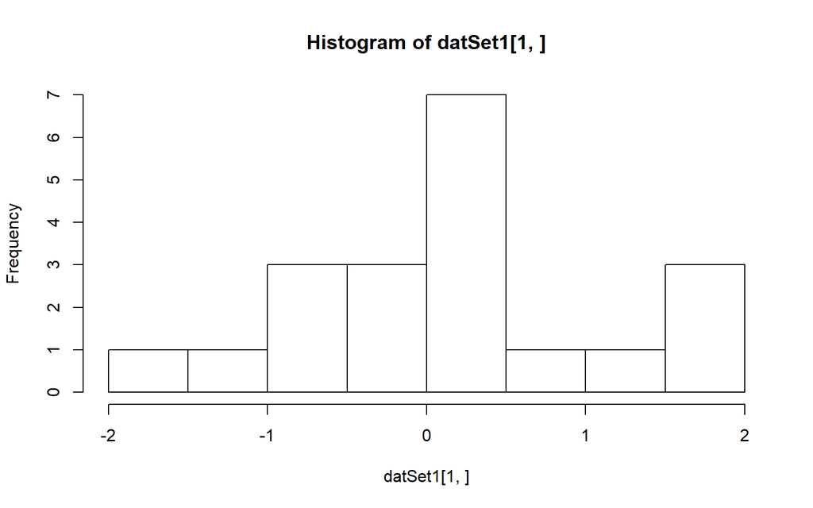

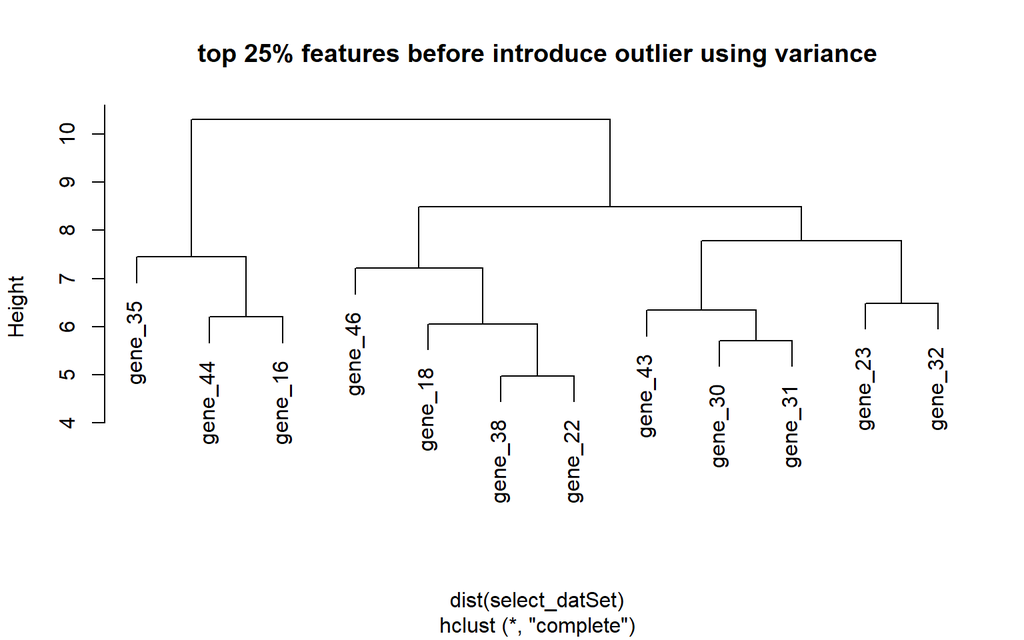

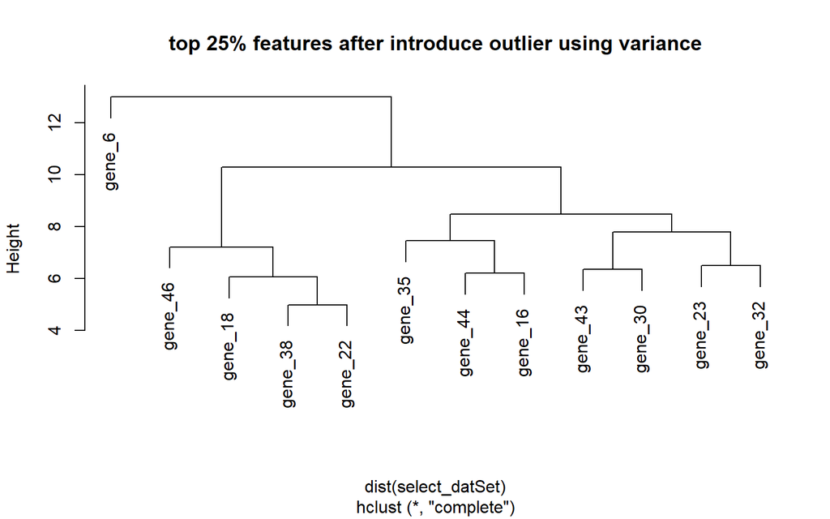

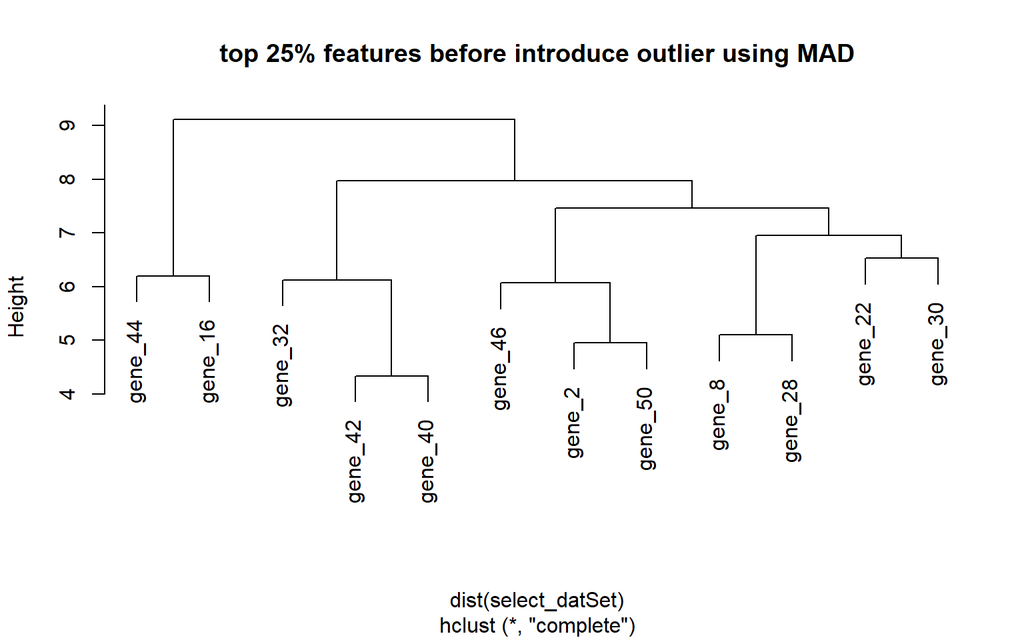

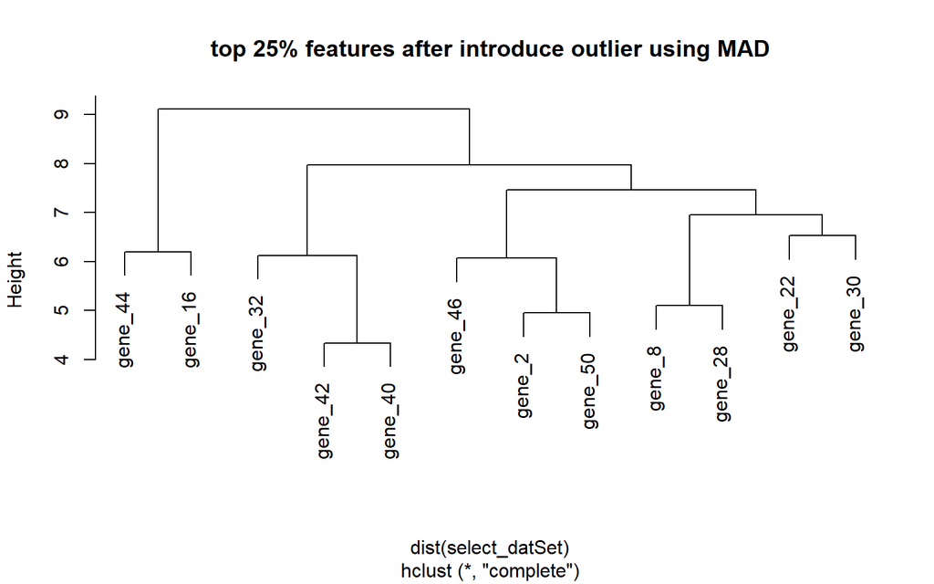

### 1.1.3 The application

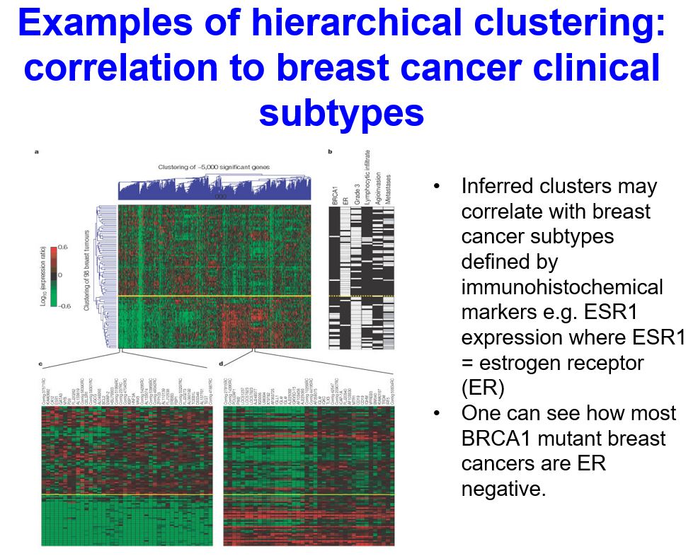

Examples of hierarchical clustering

**Question3: If we use log transformation the distance for example Euclidean distance among features will be difference.So Can we do log transformation? the transformed data is not primary data.**

**Question4: z-transformation is not advisable if the aim is to assess or compare the variability across features, but how about normalization across samples. That is for a p* n matrix X ,if you need to reduce the Dimension of rows, do we need to normalization across columns or versa.**

## 1.2 Dimensional reduction (II): Singular Value decomposition (SVD)

The helpful reference 可供参考的资源：

1. http://blog.csdn.net/Dark_Scope/article/details/53150883
2. https://www.zhihu.com/question/38319536/answer/131029607?from=profile_answer_card
3. http://www.cnblogs.com/LeftNotEasy/archive/2011/01/19/1939687.html
4. http://blog.csdn.net/ab_use/article/details/50433635

### 1.2.1 Prove1

Note that the squares of the diagonal entries are the eigenvalues of the eigenvector decomposition of the data covariance matrix (i.e. the eigenvalues of a PCA). Exercise: try to prove this!

协方差矩阵（或内积矩阵）的奇异值分解结果和特征值分解结果一致，请证明这个结论。

answer: try to see the reference, especially 1. Note in the biological context, p >> m so we use the **Reduced SVDs not the full SVD** please see the [wiki](https://en.wikipedia.org/wiki/Singular-value_decomposition#Reduced_SVDs).

特别要注意，这里用的是近似SVD，不是原版的SVD。

The PCA dimensionality reduction need to obey two rules. First is project the data matrix onto lower-dimensional linear subspaces so that the projected variance of X (our data matrix) onto these subspaces is maximal(just like teacher said). Another is Minimizing loss due to projection (Reference 1 is prove by this way) .They all lead to the same results.

PCA有两种通俗易懂的解释，1)是最大化投影后数据的方差(让数据更分散,老师上课的推导方式就是这样)；2)是最小化投影造成的损失(参考链接1就是按照这个方式来推导的)。这两个思路最后都能推导出同样的结果。

P.S.: It took me a day to understand these mathematical theory. So if you can’t understand, please be patient!

### 1.2.2 Prove2

Note that the first n eigenvalues of $XX^T$ are identical to the n eigenvalues of $X^TX$ (the rest of eigenvalues of $XX^T$ will be zero).

证明协方差矩阵和内积矩阵的共有特征值是一样的。

Assume $v$ is an eigenvector $XX^T$ to eigenvalue $\lambda\ne0$. Then it holds $XX^Tv=\lambda v$, and
$$X^TX(X^Tv) = \lambda (X^Tv).$$
Since $\lambda \ne0$, it follows $X^Tv\ne0$, hence $X^Tv$ is an eigenvector of $X^TX$ with eigenvalue $\lambda$.

That is, you obtain the eigenvectors of $X^TX$ from $X^Tv$ with $v$ eigenvector of $v$ of $XX^T$ to non-zero eigenvalue.

Note that the eigenvalues are equal, but the eigenvector not.

注意共有的特征值时一样的，但是特征向量是不一样的。

### 1.2.3 Prove3

The absolute magnitude of the weights in the columns of U and V don’t have meaning, only the relative magnitude.

U列和V列中的权重的绝对大小没有意义, 只有相对大小有意义。

Of course, we always need to use relative values to compare. **Question5: in fact, I don’t really understand this question!**

这不是显然么，我们当然要用相对值了。我不大理解这个问题。

### 1.2.4 Permutation based estimation

Note that because the singular value distribution derives from a large matrix, that randomising the data matrix again will lead to an almost identical distribution of singular values. (Exercise: check this yourself!)

请注意, 由于奇异值分布是从一个大矩阵派生的, 因此随机数据矩阵将导致奇异值的几乎相同分布。(练习: 自己检查一下!)

```r
# Create matrix that row correspond to CpGs and columns correspond to
# samples
CpGs_size <- 20000
sampleSize <- 100
SVD_datSet <- matrix(0, nrow = CpGs_size, ncol = sampleSize)
rownames(SVD_datSet) <- paste0("CpG_", 1:CpGs_size)
# assign the Gaussians distribution to each row
assignValues <- function(arg) {
    # I use the uniform distribution
    res <- runif(n = sampleSize, min = 0, max = 100)
    return(res)
}
set.seed(212)  # set seed so it could be repeatable
# use apply to avoid explict for loop
SVD_datSet <- t(apply(SVD_datSet, 1, assignValues))

singular_values <- svd(SVD_datSet)$d
# define a dataFrame to store the singlar_values
df <- data.frame(PC = paste0("PC", 1:length(singular_values)), ob = singular_values,
    x1 = 0, x2 = 0, x3 = 0, x4 = 0, x5 = 0)
permutation <- function(arg) {
    res <- sample(arg)
    return(res)
}
# run for loop
for (i in 1:5) {
    permute_datSet <- apply(SVD_datSet, 2, permutation)
    df[, i + 2] <- svd(permute_datSet)$d
}
# let's transform the absolute values to fractions and choose the first 15
# PCs
df[, 2:7] <- df[, 2:7]/colSums(df[, 2:7])
df <- df[1:15, ]
# let's see it
knitr::kable(df)
```

| PC | ob | x1 | x2 | x3 | x4 | x5 |
| --- | --- | --- | --- | --- | --- | --- |
| PC1 | 0.1491552 | 0.1491554 | 0.1491452 | 0.1491539 | 0.1491585 | 0.1491482 |
| PC2 | 0.0091942 | 0.0091832 | 0.0091623 | 0.0091710 | 0.0091489 | 0.0092023 |
| PC3 | 0.0091726 | 0.0091476 | 0.0091216 | 0.0091638 | 0.0091302 | 0.0091434 |
| PC4 | 0.0091317 | 0.0091347 | 0.0091034 | 0.0091206 | 0.0091088 | 0.0091392 |
| PC5 | 0.0091132 | 0.0091226 | 0.0091022 | 0.0091141 | 0.0090958 | 0.0091114 |
| PC6 | 0.0090887 | 0.0091145 | 0.0090861 | 0.0090981 | 0.0090896 | 0.0090763 |
| PC7 | 0.0090766 | 0.0090711 | 0.0090753 | 0.0090849 | 0.0090725 | 0.0090614 |
| PC8 | 0.0090689 | 0.0090482 | 0.0090673 | 0.0090467 | 0.0090517 | 0.0090448 |
| PC9 | 0.0090426 | 0.0090402 | 0.0090569 | 0.0090406 | 0.0090442 | 0.0090274 |
| PC10 | 0.0090361 | 0.0090273 | 0.0090455 | 0.0090261 | 0.0090376 | 0.0090188 |
| PC11 | 0.0090177 | 0.0090099 | 0.0090338 | 0.0090046 | 0.0090243 | 0.0090031 |
| PC12 | 0.0089998 | 0.0089912 | 0.0090067 | 0.0089936 | 0.0090098 | 0.0089951 |
| PC13 | 0.0089943 | 0.0089887 | 0.0089923 | 0.0089811 | 0.0089962 | 0.0089896 |
| PC14 | 0.0089795 | 0.0089728 | 0.0089719 | 0.0089766 | 0.0089778 | 0.0089778 |
| PC15 | 0.0089617 | 0.0089445 | 0.0089523 | 0.0089707 | 0.0089604 | 0.0089562 |

So amazing! singular values are almost identical distribution.

可以很神奇地看到，多次扰动后奇异值的分布几乎是不变的。

**Question6: SVD avoids the multiple-testing problem? We still need to do multiple test since there are many components, How could we avoid ?**

### 1.2.5 Homework Exercise

The website of GEO is unstable so I decide to do this later!

鉴于GEO 网站上不去，等以后有时间再做。

## 1.3 Dimensional reduction (III): Multivariate analysis:

### 1.3.1 Prove1.

For a linear model $R^2 = \rho ^2$:

I find a website could be helpful to understand: https://math.stackexchange.com/questions/1489414/why-is-r2-rho2/1489868 .

**Question7: I just find the prove for one variable regression. Is this true for Multivariate regression? if so, PCC if between which vecter? y_hat and y ?**

### 1.3.2 Prove2

Prove the Frisch-Waugh-Lovell Theorem.

### 1.3.3 Homework exercise:

Thank you for the teacher, he has already write the code for us! 感谢老师贡献给我们代码。

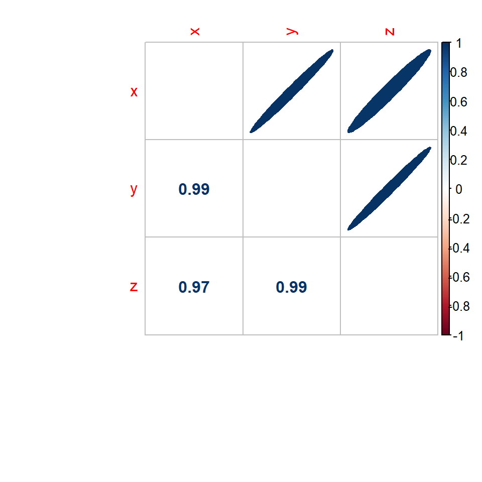

```r
### TestPCOR.R

### define parameters
ns <- 100;
e <- 0.5;
s <- 3;
### construct data matrix
x <- rnorm(ns,0,s);
y <- x + rnorm(ns,0,e);
z <- y + rnorm(ns,0,e);
data.m <- rbind(x,y,z);
rownames(data.m) <- c("x","y","z");
#### compute Pearson correlations and estimate P-values
cor.m <- cor(t(data.m));
#visualize the results
corrplot::corrplot.mixed(cor.m,
               order = "hclust",
               tl.pos = "lt",
               upper = "ellipse")
```

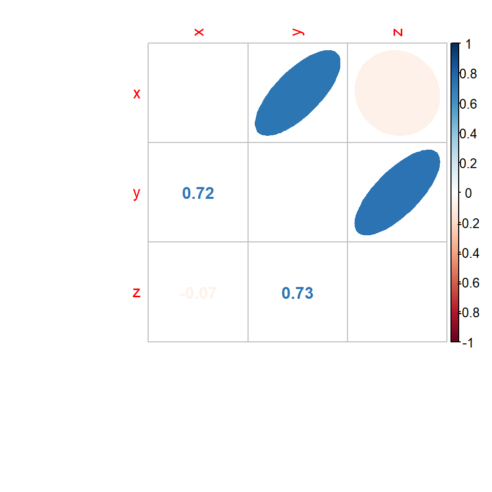

```r
# print the p-value

cor.p <- c(cor.test(x,y)$p.value,cor.test(x,z)$p.value,cor.test(y,z)$p.value);
names(cor.p)  <- c("xy","xz","yz");
diag(cor.m) <- 0; ### self-correlations not of interest.
### Fisher-transform
z.m <- 0.5*log( (1+cor.m)/(1-cor.m) )
pv.m <- 2*pnorm(abs(z.m),0,sd=1/sqrt(ns-3),lower.tail=FALSE);

### now obtain Partial correlations
cov.m <- cov(t(data.m));
icov.m <- solve(cov.m); ### find inverse covariance

### now store partial correlation values in a vector
pcor.v <- vector();
ii <- 1;
for(i in 1:2){
    for(j in (i+1):3){
      pcor.v[ii] <- -icov.m[i,j]/sqrt(icov.m[i,i]*icov.m[j,j]);
      ii <- ii+1;
    }
}
names(pcor.v) <- c("xy","xz","yz");
pcor.m <- cor.m
pcor.m[1,2] <- pcor.v[1] -> pcor.m[2,1]
pcor.m[1,3] <- pcor.v[2] -> pcor.m[3,1]
pcor.m[2,3] <- pcor.v[3] -> pcor.m[3,2]
corrplot::corrplot.mixed(pcor.m,
               order = "hclust",
               tl.pos = "lt",
               upper = "ellipse")
```

```r
### now establish significance of partial correlations using permutation approach
nMC <- 10000;
pcorMC.m <- matrix(NA,nrow=nMC,ncol=3);
colnames(pcorMC.m) <- names(pcor.v);
for(p in 1:nMC){
    dataP.m <- data.m;
    for(r in 1:nrow(data.m)){
       dataP.m[r,] <- data.m[r,sample(1:ns,ns,replace=FALSE)];
    }
    corP.m <- cor(t(dataP.m));
    diag(corP.m) <- 0;
    zP.m <- 0.5*log( (1+corP.m)/(1-corP.m) )
    pvP.m <- 2*pnorm(abs(zP.m),0,sd=1/sqrt(ns-3),lower.tail=FALSE);
    covP.m <- cov(t(dataP.m));
    icovP.m <- solve(covP.m);

    pcorP.v <- pcor.v;
    ii <- 1;
    for(i in 1:2){
     for(j in (i+1):3){
      pcorP.v[ii] <- -icovP.m[i,j]/sqrt(icovP.m[i,i]*icovP.m[j,j]);
      ii <- ii+1;
     }
    }
    pcorMC.m[p,] <- pcorP.v;
    #print(p);
}

#### obtain empirical P-values for partial correlations
pcorPV.v <- vector();
for(i in 1:3){
   pcorPV.v[i] <- length(which(pcorMC.m[,i] > pcor.v[i]))/nMC;
}
# print the p-value
pcorPV.v
```

```
[1] 0.0000 0.7562 0.0000
```

```r
### you should find that whereas all off-diagonal entries of pv.m are highly significant, so you get edges x-y, x-z and y-z, for partial correlations, only 1st and 3rd entries of pcorPV.v should be highly statistically significant, so only edges x-y and y-z are direct.
```

So from the code the above, we could see the difference between *Pearson correlations* and *Partial correlations*.

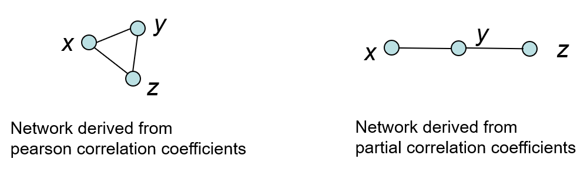

Networks

2017-11-27